# Deconvolution

Florian Bouchet

Packages and functions that will be useful:

```r
# Loading packages
library(SummarizedExperiment)
library(edgeR)
library(EnsDb.Hsapiens.v86)
library(ConsensusTME)
library(ggplot2)
library(cowplot)
library(dplyr)
library(rpart)
library(rpart.plot)

# Loading functions
source(file = "colplotclust.R")
source(file = "plotclust.R")
source(file = "grouptest.R")
```

We load the data that will be used:

```r
# Loading the clean expression data
load(file = "dataclean.rda")
data
```

```
class: RangedSummarizedExperiment
dim: 60660 1094
metadata(1): data_release
assays(6): unstranded stranded_first ... fpkm_unstrand fpkm_uq_unstrand
rownames(60660): ENSG00000000003.15 ENSG00000000005.6 ...
  ENSG00000288674.1 ENSG00000288675.1
rowData names(10): source type ... hgnc_id havana_gene
colnames(1094): TCGA-GM-A2DL-01A-11R-A18M-07
  TCGA-AC-A2QI-01A-12R-A19W-07 ... TCGA-D8-A1J9-01A-11R-A13Q-07
  TCGA-V7-A7HQ-01A-11R-A33J-07
colData names(97): barcode patient ... paper_PARADIGM Clusters
  paper_Pan-Gyn Clusters
```

```r
# Loading the 'countsER'mod table
load(file = "countsERmod.rda")
head(countsERmod)
```

```
                                counts ER_level wardD2_3  kmeans3  wardD2_2
TCGA-GM-A2DL-01A-11R-A18M-07  8.302874     >50%     High Moderate ModToHigh
TCGA-AC-A2QI-01A-12R-A19W-07  8.884623     >50%     High     High ModToHigh
TCGA-EW-A1PD-01A-11R-A144-07  9.437988     >50%     High     High ModToHigh
TCGA-AO-A12D-01A-11R-A115-07  3.220600      <1%      Low      Low  LowToMod
TCGA-AR-A24N-01A-11R-A169-07 10.449212   10-50%     High     High ModToHigh
TCGA-A2-A0YL-01A-21R-A109-07  7.835026     >50%     High Moderate ModToHigh
                             complete2 kmeans_GMM2
TCGA-GM-A2DL-01A-11R-A18M-07 ModToHigh   ModToHigh
TCGA-AC-A2QI-01A-12R-A19W-07 ModToHigh   ModToHigh
TCGA-EW-A1PD-01A-11R-A144-07 ModToHigh   ModToHigh
TCGA-AO-A12D-01A-11R-A115-07  LowToMod    LowToMod
TCGA-AR-A24N-01A-11R-A169-07 ModToHigh   ModToHigh
TCGA-A2-A0YL-01A-21R-A109-07 ModToHigh   ModToHigh
```

```r
# Loading the DGElist
load(file = "listdge.rda")
```

### DECONVOLUTION ANALYSIS

We will perform a deconvolution analysis from normalized counts. First, Ensembl gene identifiers must be converted to HGNC (HUGO Gene Nomenclature Committee) gene identifiers and we will use the annotation database provided by Ensembl for that purpose.

```r
# Creating a new assay with normalized counts in the 'data' object
assays(data)$countsnorm <- cpm(listdge, log = T)
# Removing the version numbers of the genes and then removing duplicated genes
# (keeping only the first versions)
rownames(data) <- sub("\\..*", "", rownames(data))
data <- data[!duplicated(rownames(data)), ]

# Converting the identifiers and using them as secondary row names (when
# specifying 'withDimnames=FALSE')
dimnames(assays(data, withDimnames = FALSE)$countsnorm) <- list(AnnotationDbi::mapIds(EnsDb.Hsapiens.v86,
    rownames(data), keytype = "GENEID", column = "SYMBOL"), colnames(data))

# Creating a matrix object with the HGNC identifiers
datamatrix <- assays(data, withDimnames = FALSE)$countsnorm
# Checking the duplicated identifiers
table(!duplicated(rownames(datamatrix)))  # 5188 duplicated
```

```
FALSE  TRUE
 5188 55428
```

```r
# Running the proper deconvolution analysis for which we need to remove the
# duplicated genes
deconvol <- consensusTMEAnalysis(datamatrix[!duplicated(rownames(datamatrix)), ],
    cancer = "BRCA", statMethod = "ssgsea")
```

```
Producing ConsensusTME Estimates Using The Following Parameters:
 Statistical Framework: "ssgsea"
 Gene Sets For Cancer Type: "BRCA"
 Sample Size: 1094
```

```r
deconvol <- t(deconvol)

# Relative abundance scores for the samples of interest (omitting the
# 'Unspecified' cases)
deconvolmod <- deconvol[rownames(countsERmod), ]
```

### CORRELATIONS AND BIPLOTS OF ABUNDANCE SCORES VS. ESR1

Let’s explore the correlations between ESR1 and the cell type abundances estimated by deconvolution and generate bivariate plots:

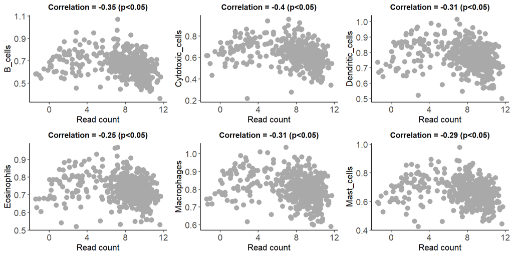

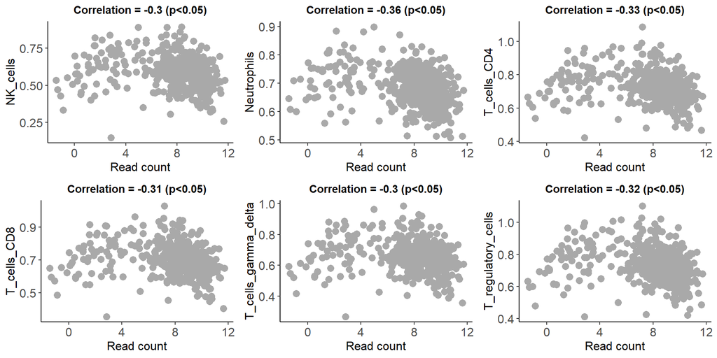

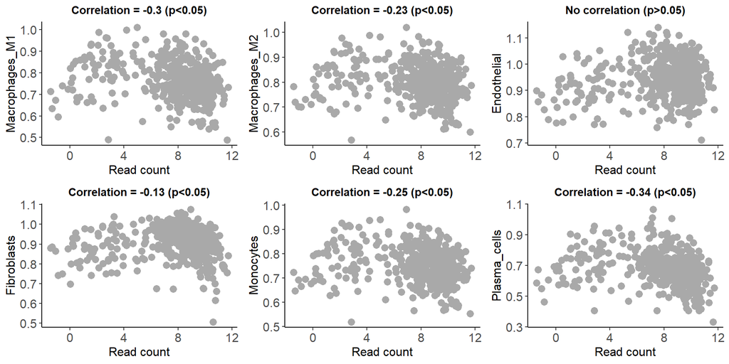

```r
# Table combining abundance scores and all variables from 'countsERmod'
combined <- data.frame(deconvolmod, countsERmod)

# Generating correlations and bivariate plots
plotlist <- lapply(colnames(combined)[1:19], function(cell) {

    # Correlation
    correl <- cor.test(combined$counts, combined[, cell], method = "spearman")

    # Bivariate plot
    plotclust(data = combined, xvar = "counts", yvar = cell, type = "biplot", col = "darkgray") +
        labs(x = "Read count", title = ifelse(correl$p.value < 0.05, paste0("Correlation = ",
            round(correl$estimate, 2), " (p<0.05)"), paste("No correlation (p>0.05)"))) +
        theme(plot.title = element_text(face = "bold", hjust = 0.5, size = 11), axis.title = element_text(size = 12))

})

# Grids with 6 plots
for (i in seq(1, length(plotlist) - 1, by = 6)) {
    print(plot_grid(plotlist = plotlist[i:(i + 5)], nrow = 2, ncol = 3))
}
```

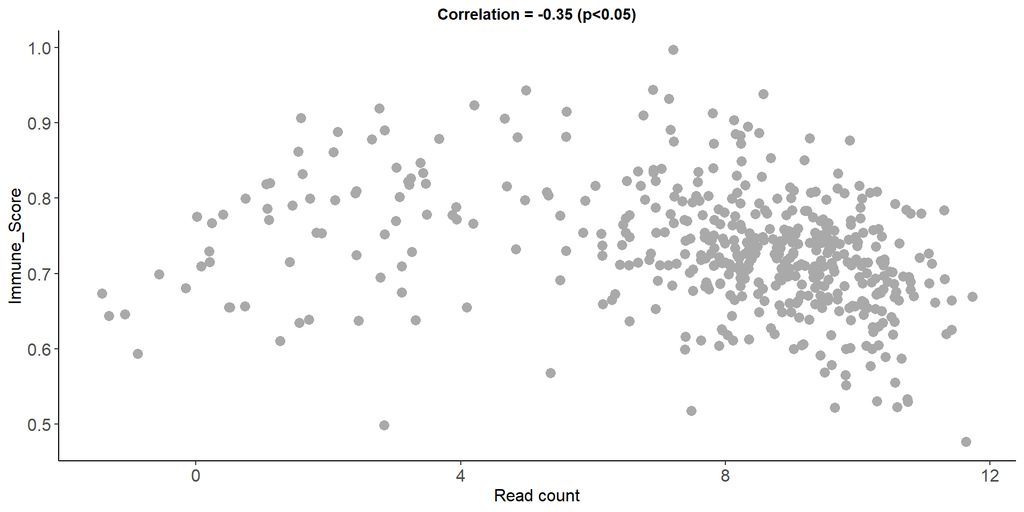

```r
# Immune score only
plotlist[[19]]
```

The correlations with ESR1 are significant for all cell types except for the endothelial cells. The significant correlations are always negative. All correlations range from 0.13 to 0.40 so that we can conclude that there is weak correlation between ESR1 expression and the abundance scores for the different cell types. Interestingly, the relationships seem not to be a single linear relationship, confirming the use of Spearman’s correlations. In particular, we observe that for read counts inferior to approximately 6 the relative abundances increase whereas for higher read counts those decrease. It can be illustrated by mean of a broken stick regression:

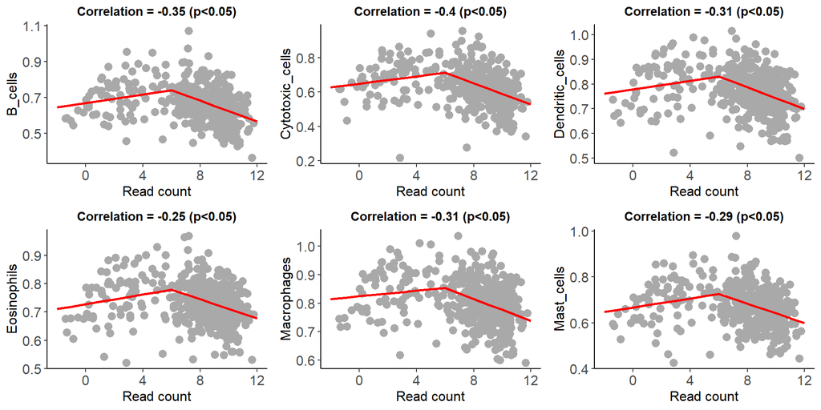

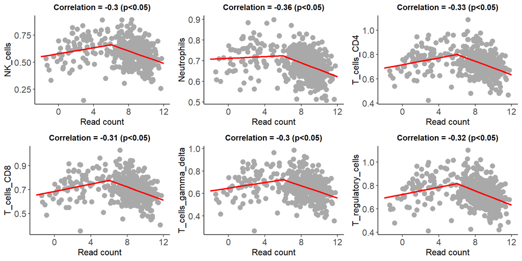

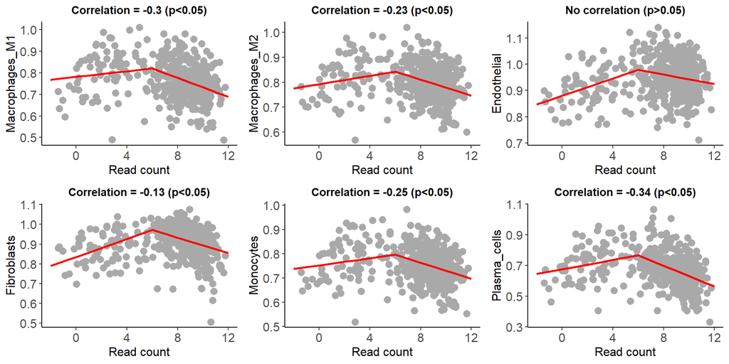

```r
# Generating correlations and bivariate plots
plotlist <- lapply(colnames(combined)[1:19], function(cell) {

    # Correlation
    correl <- cor.test(combined$counts, combined[, cell], method = "spearman")

    # Broken stick linear model to obtain intercept and regression coefficients
    lhs <- function(x) ifelse(x < 6, 6 - x, 0)
    rhs <- function(x) ifelse(x < 6, 0, x - 6)
    lmodcoeff <- lm(combined[, cell] ~ lhs(combined$counts) + rhs(combined$counts))$coefficients

    # Matrix containing the predicted Y values over a range of X values
    # covering the observed X value range
    xseq <- seq(-2, 12)
    yval <- lmodcoeff[1] + lmodcoeff[2] * lhs(xseq) + lmodcoeff[3] * rhs(xseq)
    df <- data.frame(xseq = xseq, yval = yval)

    # Bivariate plot with the double abline
    plotclust(data = combined, xvar = "counts", yvar = cell, type = "biplot", col = "darkgray") +
        geom_line(data = df, aes(x = xseq, y = yval), colour = "red", linewidth = 1) +
        labs(x = "Read count", title = ifelse(correl$p.value < 0.05, paste0("Correlation = ",
            round(correl$estimate, 2), " (p<0.05)"), paste("No correlation (p>0.05)"))) +
        theme(plot.title = element_text(face = "bold", hjust = 0.5, size = 11), axis.title = element_text(size = 12))

})

# Grids with 6 plots
for (i in seq(1, length(plotlist) - 1, by = 6)) {
    print(plot_grid(plotlist = plotlist[i:(i + 5)], nrow = 2, ncol = 3))
}
```

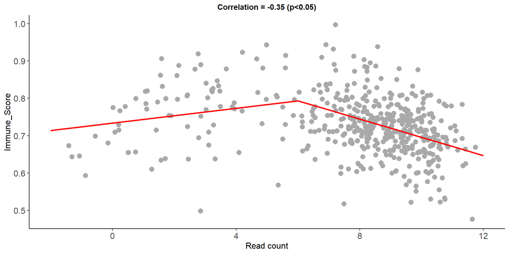

```r
# Immune score only
plotlist[[19]]
```

The relationships appear clearer with the help of the broken stick regression. The increase in relative abundances when read counts are inferior to 6 could make sense biologically: If tumors with read counts inferior to 6 correspond in fact to ER-negative and ER-low/ER-moderate-positive tumors (and the others to ER-high-positive tumors) it indeed translates the more inflamed TME of such tumors previously evidenced in the literature.

We can save the table *combined*:

#save(combined, file=“combined.rda”)

### AMONG-GROUP COMPARISONS OF THE CLASSIFICATIONS BASED ON ABUNDANCE SCORES

We will generate boxplots to compare the abundances scores among the investigated classification, for each cell type.

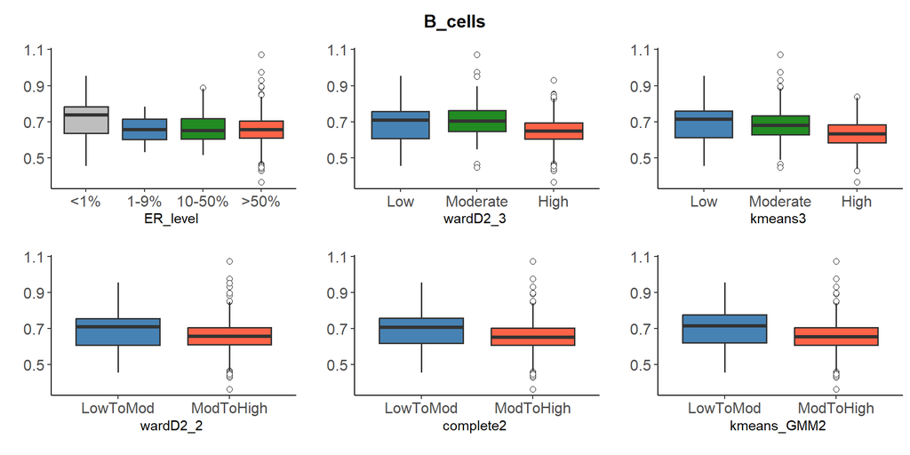

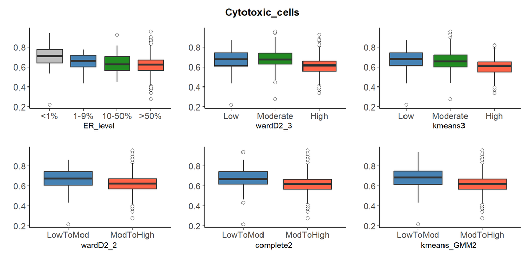

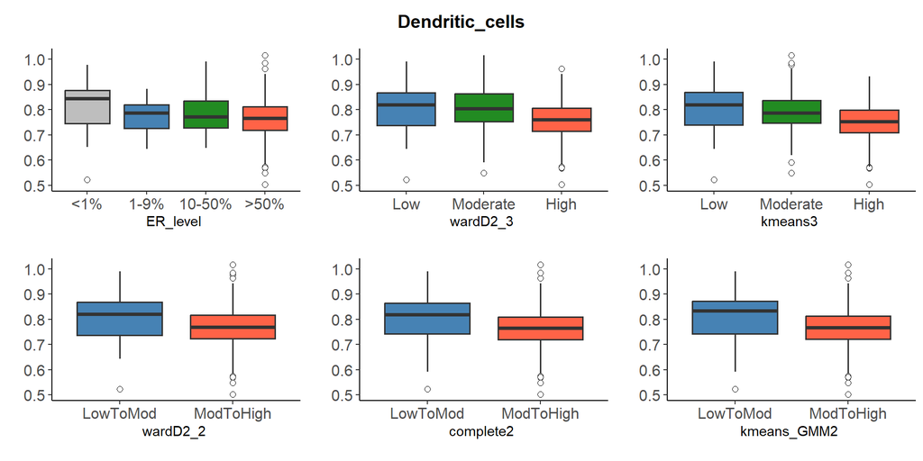

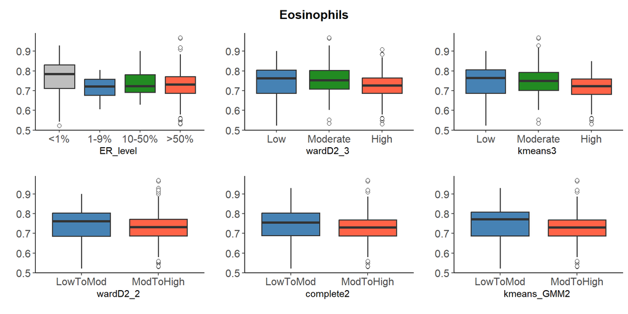

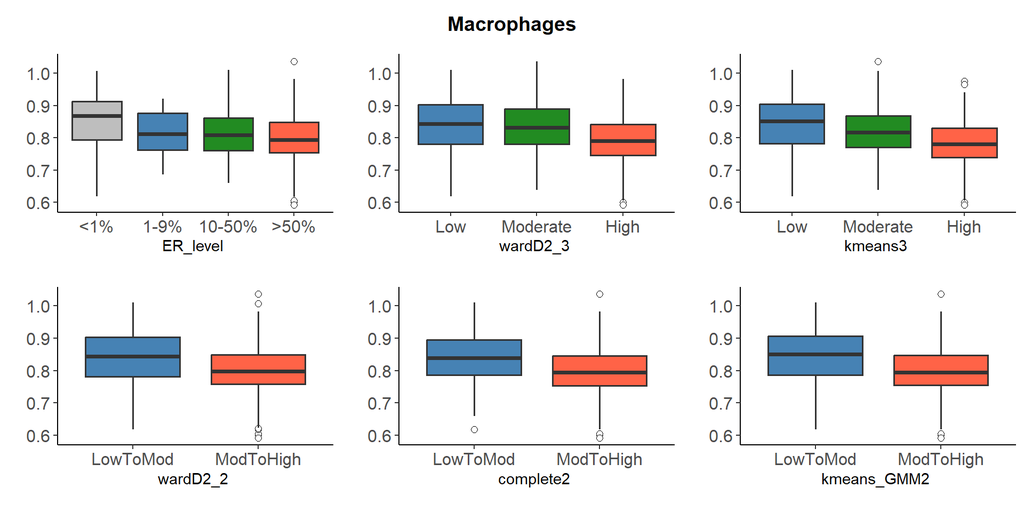

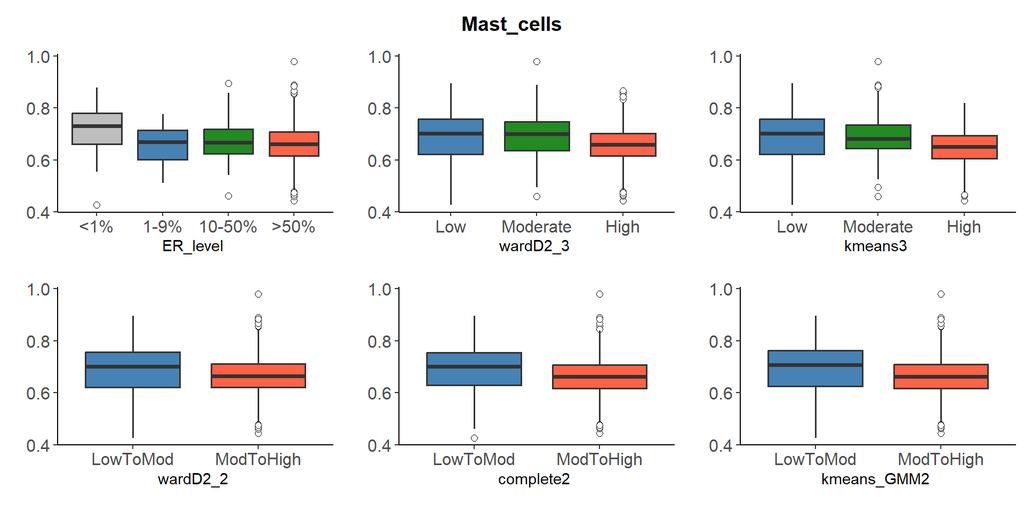

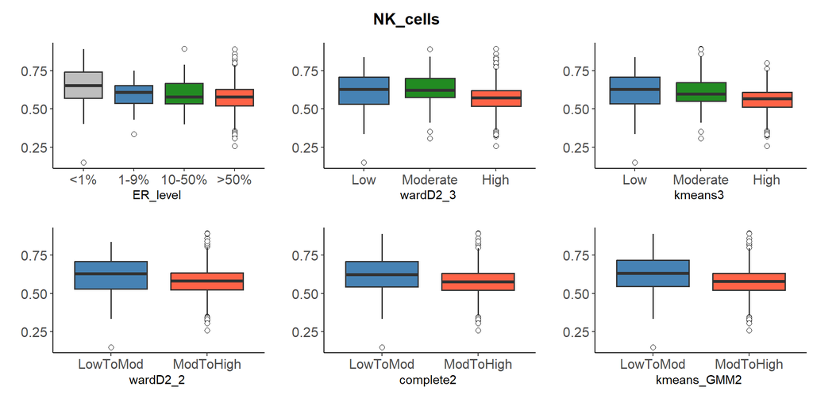

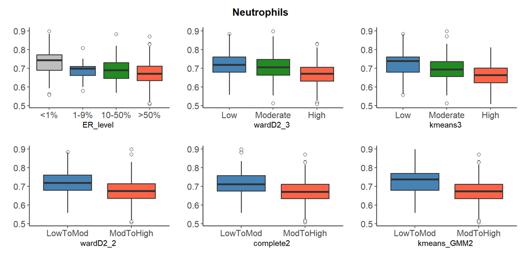

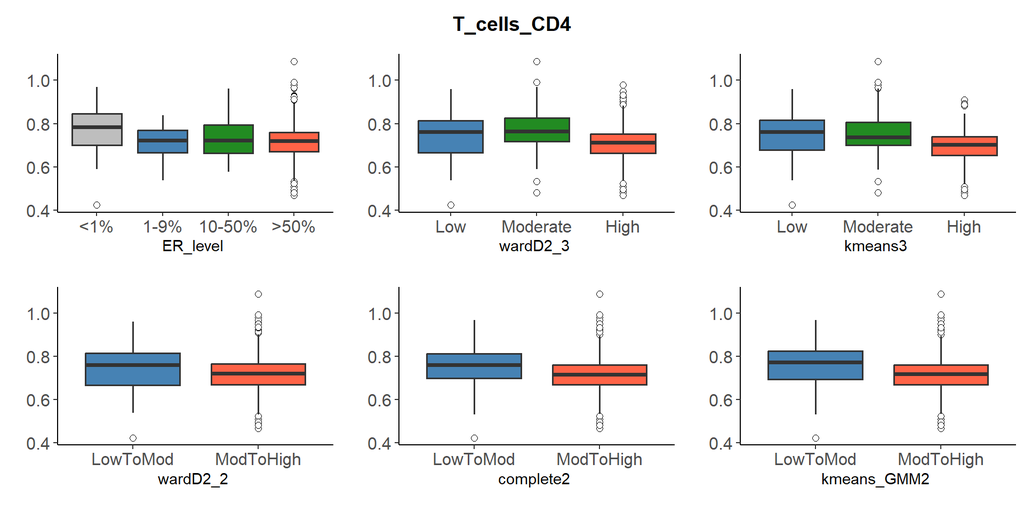

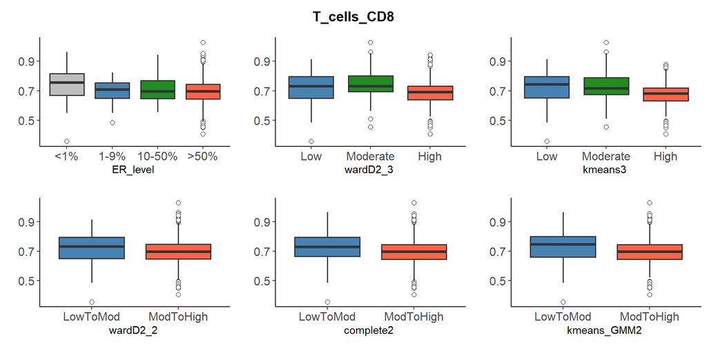

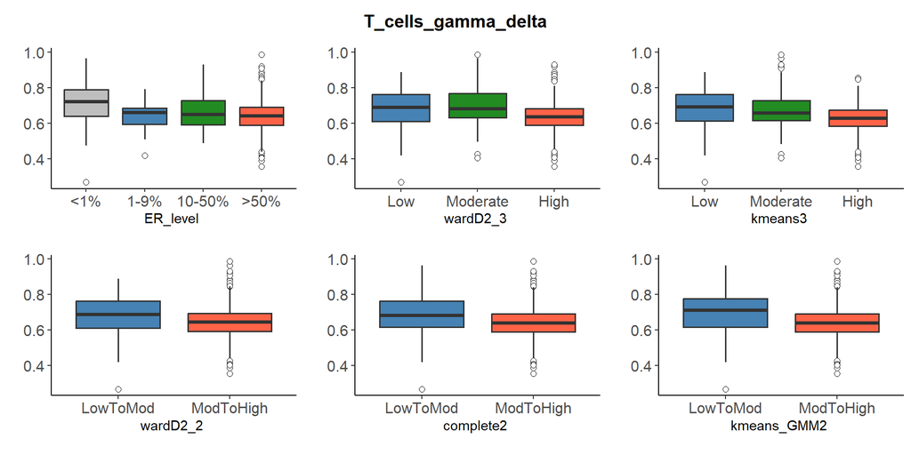

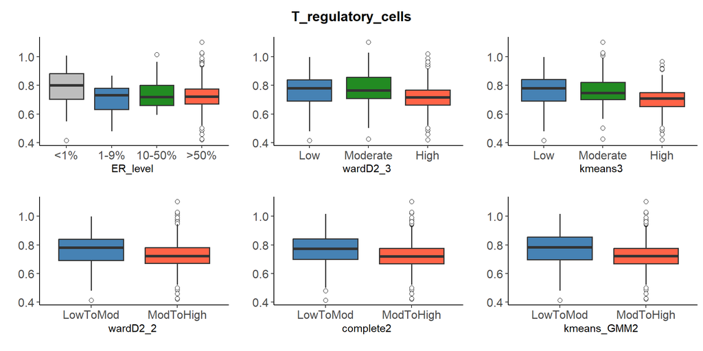

[7 more figures not shown]

```r
# Loop for generating compound grids with the boxplot for each investigated
# classification
for (cell in colnames(combined)[1:19]) {
    plotlist <- lapply(colnames(combined)[21:26], FUN = function(cluster) {
        colbox <- colplotclust(classif = cluster, data = combined, type = "group")
        plotclust(data = combined, xvar = cluster, yvar = cell, col = colbox$col,
            type = "boxplot", title = F) + labs(x = paste(cluster, "\n"), y = "")
    })

    # Grid with all plots
    grid <- plot_grid(plotlist = plotlist, nrow = 2)
    # Common title
    title <- ggdraw() + draw_label(cell, fontface = "bold")
    # Final figure
    print(plot_grid(title, grid, ncol = 1, nrow = 2, rel_heights = c(0.1, 1)))
}
```

We observe the following: For the IHC classification, the general pattern is that the higher the ESR1 expression levels, the lower the abundance scores. However, the pattern varies sometimes with for example the “10-50%” category that has higher scores than the “1-9%” category. This pattern is also reversed in the case of the endothelial cells and fibroblasts.

The alternative ternary classifications show a similar general pattern: the higher the ESR1 expression levels, the lower the abundance scores, also with variation. The differences are less marked between the “Low” and “Moderate” categories than with the “High” category, but are somewhat more pronounced for the *kmeans3* classification. The pattern is also reversed for the endothelial cells and fibroblasts, except that in these cases, the “Moderate” category has the highest scores.

Regarding alternative binary classifications, the results are also very similar from one classification to another. The general pattern is confirmed and is somewhat easier to observe since there are only two categories. The inverted pattern is again confirmed for the endothelial cells and fibroblasts. The differences appear somewhat more pronounced in the case of the *kmeans_GMM2* classification.

The next step is to verify whether the differences between categories are significant or not (overall and pairwise differences). We check for each investigated classification separately:

```r
# Example for the IHC categories (not run here)
for (cell in colnames(combined)[1:19]) {
    grouptest(cell, "ER_level", combined)
}
# To generate the results for the other classifications, one simply has to
# replace 'ER_level' with 'wardD2_3', 'kmeans3', 'wardD2_2', 'complete2', or
# 'kmeans_GMM2'
```

All the results can be found in the following files: *IHC_comp_TME.txt*, *Ward_Ternary_comp_TME.txt*, *KM_Ternary_comp_TME.txt*, *Ward_Binary_comp_TME.txt*, *Complete_Binary_comp_TME.txt*, and *KM_Binary_comp_TME.txt*.

- Traditional IHC classification: The “<1%” category always differs significantly from the “>50%” category. It further differs from the “10-50%” category except for the dendritic cells, eosinophils, CD8 T cells, M2 macrophages, endothelial cells, and monocytes. The “<1%” category also differs from the “1-9%” category but only for eosinophils and plasma cells. The immune score shows significant differences between the “<1%” and “>50%” categories only.

These results partially agree with those of Voorwerk et al. (2023): The “<1%” category does not differ from the “1-9%” category (except for the two cell type mentionned above), nor from the “10-50%” category, but only for the CD8 T cells. In addition, the “1-9%” and “10-50%” categories do not differ form each other either. Finally, the “<1%” and “>50%” categories always differ significantly. However, both the “1-9%” and “10-50%” categories never differ significantly from the “>50%” category (unlike in the results of Voorwerk et al., 2023). It should be remembered nonetheless that conducting a precise comparison is difficult since Voorwerk et al. (2023) directly analyzed cell percentages (instead of abundance scores, as we did) and only evaluated two general cell types (stromal TILs and stromal CD8 cells) instead of individual cell types (as in most cases here). More specific comparisons based on more comparable results will be conducted in a next step.

- Alternative ternary classifications: The “High” category always differs significantly from the “Low” and “Moderate” categories, except for the M2 macrophages (no differences between “Low” and “High”) and endothelial cells (no differences between “Moderate” and “High”) in the case of *wardD2_3*, and the fibroblasts (no differentiation between “Low” and “High”) in the case of *kmeans_3*. Differences are also significant when comparing the “Moderate” and “Low” categories, but only for the fibroblasts and endothelial cells (both classifications), as well as the neutrophils (*kmeans_3* only). The immune score shows significant differences between the “High” and “Low” as well as between the “High” and “Moderate” categories.
- Alternative binary classifications: The two categories (“LowToMod” and “ModToHigh”), always differ significantly. the only exceptions are the M2 macrophages and monocytes in the case of *wardD2_2* only.

### COMPARISONS OF THE CLASSIFICATIONS USING A PCA BASED ON THE ABUNDANCE SCORES

Finally, it may be interesting to investigate whether the various categorizations are reflected when applying a PCA using all abundance scores:

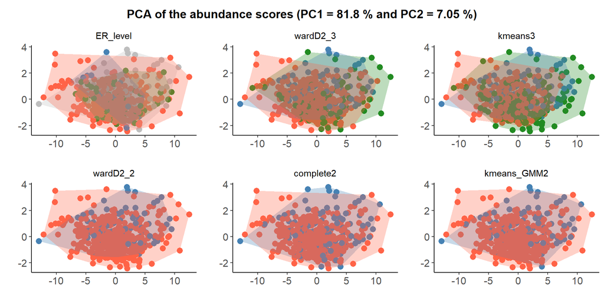

```r
# PCA with percentages of variance explained by the first two PCs
acp <- prcomp(combined[1:19], scale. = T)  # We scale the data (standardization) to ensure that cell types with larger variance do not dominate
perc <- round(acp$sdev^2/sum(acp$sdev^2) * 100, 2)

# Generating the list of PCA plots
plotlist <- lapply(colnames(combined)[21:26], FUN = function(cluster) {
    colorgplot <- colplotclust(classif = cluster, data = combined, type = "single")  # Point colors
    hulls <- as.data.frame(acp$x[, 1:2]) %>%
        mutate(investclassif = combined[, cluster]) %>%
        group_by(investclassif) %>%
        slice(chull(PC1, PC2)) %>%
        ungroup() %>%
        as.data.frame()  # Convex hulls for each category, for which it is first needed to have a table with both the PC scores and the category labels
    plotclust(data = acp$x, xvar = 1, yvar = 2, col = colorgplot$col, type = "biplot",
        title = F) + geom_polygon(data = hulls, aes(x = PC1, y = PC2, fill = colplotclust(classif = "investclassif",
        data = hulls, type = "single")$col), alpha = 0.3) + scale_fill_identity() +
        labs(x = "", y = "", title = cluster) + theme(plot.title = element_text(hjust = 0.5,
        size = 11))
})

# Grid with all plots
grid <- plot_grid(plotlist = plotlist, nrow = 2)
# Common title
title <- ggdraw() + draw_label(paste("PCA of the abundance scores", "(PC1 =", perc[1],
    "%", "and PC2 =", perc[2], "%)"), fontface = "bold")
# Final figure
print(plot_grid(title, grid, ncol = 1, nrow = 2, rel_heights = c(0.1, 1)))
```

No particular groupings stand out in the PCA. The categorization is not reflected either, for any of the investigated classification. The overlap is almost complete (for all categories of all investigated classifications).

In terms of cell type abundances, and leaving the PCA results apart, we have seen that the binary classifications (almost) systematically show significant differences between their two categories. The pairwise group differences are not always significant in the case of the IHC and alternative ternary classifications. The signal is robust when comparing extremes categories but remains the problem of the intermediate categories (especially “1-9%” and “Moderate”) that are not always differentiated from the others. Binary classifications can be considered parsimonious alternatives when more groups (categories) do not give clear biological signal (clear biological differentiation).

### GENERALIZED COMPARISONS OF THE CLASSIFICATIONS BASED ON RELEVANT IMMUNOLOGICAL FEATURES

To go further and try determining which classification is the optimal in terms of biological (immunological) signal—that is to say to have a global view of which one best distinguishes between its categories biologically-wise, we will select representative immunological features, and for each of them use global among-groups differentiation metrics and characteristics to compare all investigated classifications at once. In that case the most representative immunological cell types would be the best markers directly associated with the antitumor immune response and the immune evasion phenotype (both lymphoid and myeloid cells): The lymphocytes types B and T (CD4+, CD8+, and regulatory), the NK cells, and the macrophages (M1, M2, and non-polarized). The mast cells and immune score are useful here as well, the first because of their positive relationship to ER expression (see Voorwerk et al., 2023) and the second because of being an overall measure of immune cell abundance.

We will thus produce summary tables with various important elements:

1. The adjusted p-value of the primary among-group comparison test. Since we compare the 6 investigated classifications the p-value is adjusted by 6, using the FDR method (Benjamini-Hochberg correction). We do not consider the 10 variables in the correction since we generate a separate summary table for each.
2. The absolute median difference and gradient of the medians. The gradient corresponds to the category ordering according to their respective median values (from lowest to highest). The order is given if it is logical (e.g., “Low Moderate High” or “High Moderate Low”) and “Unordered” is displayed otherwise.
3. The effect size (and its interpretation) and effect size measure used. The effect size measure applied depends on the primary among-group comparison test used: for binary classifications, Cohen’s D if it is Student’s T and Cliff’s Delta if it is Mann-Whitney. For the other classifications, Epsilon squared if it is Kruskal-Wallis, Eta squared if it is ANOVA, and Approximate Eta squared if it is Welch’s ANOVA (these three metrics are the corresponding default metrics of the *effectsize()* function). The interpretation of values (small, moderate, or high effect) is based on *In and Lee (2024)*.

Our function *grouptest()* allows saving small tables in *.csv* format with some of these measures (the rest is directly printed in the console) so that it is needed to run the function separately for each immunological feature:

```r
# Vector with considered immunological features
celltype <- colnames(combined)[c(1, 9, 10, 12, 7, 13, 14, 5, 6, 19)]

# Applying the function 'grouptest()' with the correct parameters Here it is
# showed for the first feature only
for (cluster in colnames(combined)[c(21:26)]) {
    grouptest(celltype[1], cluster, combined, resulttest = F, mediancomp = T, pvaladj = T,
        ncomps = 6, magnitude = T, writetable = T)
}  # Repeat for all elements in celltype (celltype[2], celltype[3], ..., celltype[10])
```

The final summary tables (for all immunological features) can be found in the *Summary_tables_classification_comparisons.xlsx* document.

The two alternative classifications that appear to best distinguish between their categories overall are systematically *kmeans3* (for the ternary classifications) and *kmeans_GMM2* (for the binary classifications). These are essentially the ones with the highest effect size (see the interpretation column). These always show a significant adjusted p-value and ordered gradient of medians. It can be observed that on several occasions the adjusted p-value is not even significant in the case of *wardD2_2*. In half of the cases the IHC classification shows an unordered gradient.

The fact that the ternary K-means classification (as well as the binary one) shows better overall differentiation than the IHC classification supports the hypothesis that an alternative classification can be biologically more relevant than the traditional IHC thresholds. In addition, the fact that a perfect gradient of medians isn’t always observed in the IHC classification and that the effect sizes are generally small further coincide with this hypothesis that the traditional ER thresholds doesn’t necessarily reflect the underlying biology of tumors.

*kmeans3* and *kmeans_GMM2* appear to be good candidate classifications with regards to the underlying biology of breast tumors. Now we have enough evidence to at least prioritize these two classifications over the others.

### SUPPLEMENTARY ANALYSIS WITH CART

At that stage it can be convenient to use the CART algorithm to search for most adequate and concrete divisions in the ESR1 data using the investigated classifications. Since we previously highlighted the relevance of the alternative classifications *kmeans3* and *kmeans_GMM2* we will apply CART on these two, as well as on the traditional IHC classification.

Let’s start with the latter:

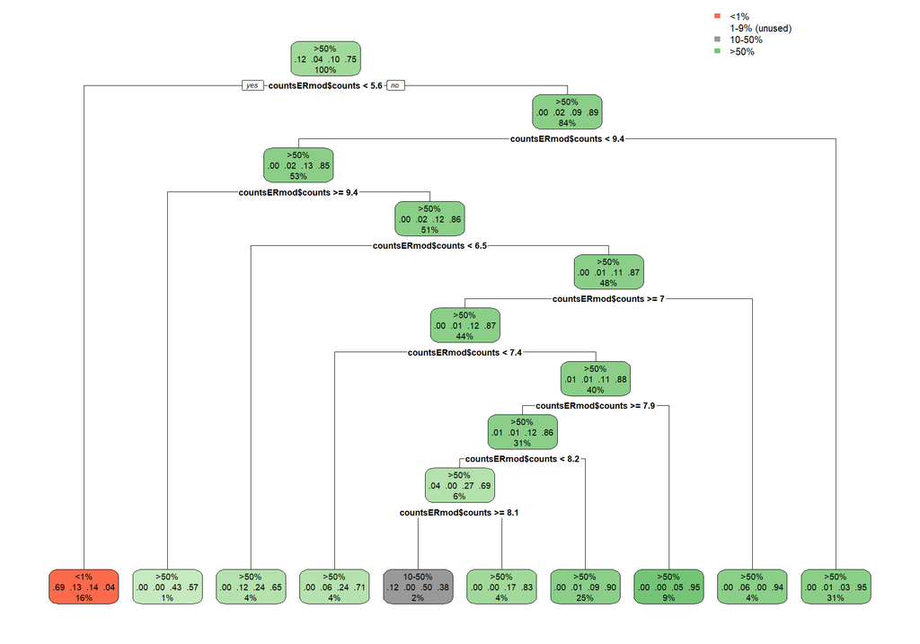

```r
# Base model for IHC
cart <- rpart(countsERmod$ER_level ~ countsERmod$counts, method = "class", cp = 0)
rpart.plot(cart)  # plot
```

```r
# Contigency table
table(predict(cart, countsERmod["counts"], type = "class"), countsERmod$ER_level)
```

```
         <1% 1-9% 10-50% >50%
  <1%     53   10     11    3
  1-9%     0    0      0    0
  10-50%   1    0      4    3
  >50%     0    7     32  345
```

We observe that most observations are classified into the “<1%” or “>50%” categories, only a few on the “10-50%” category, and none on the “1-9%” category. This is another indication that the two extreme categories are well separated, but the others are much less, and that there would be only one intermediate category, like a ternary classification. The resulting tree suggests no less than nine cutoffs, some being very similar and even two that are virtually the same but expressed differently (“< 9.4” and “≥ 9.4”), which seem unreasonable results. Now we will calculate the complexity parameter (cp), which minimizes the relative prediction error (from cross-validation) and see how the tree can be pruned:

```r
# CP that gives the smallest xerror
(bestcp <- cart$cptable[which.min(cart$cptable[, "xerror"]), "CP"])
```

```
[1] 0.001059322
```

Indeed, the cp that minimizes the xerror is 0.001059322. We can prune the tree with this value and look at the new results:

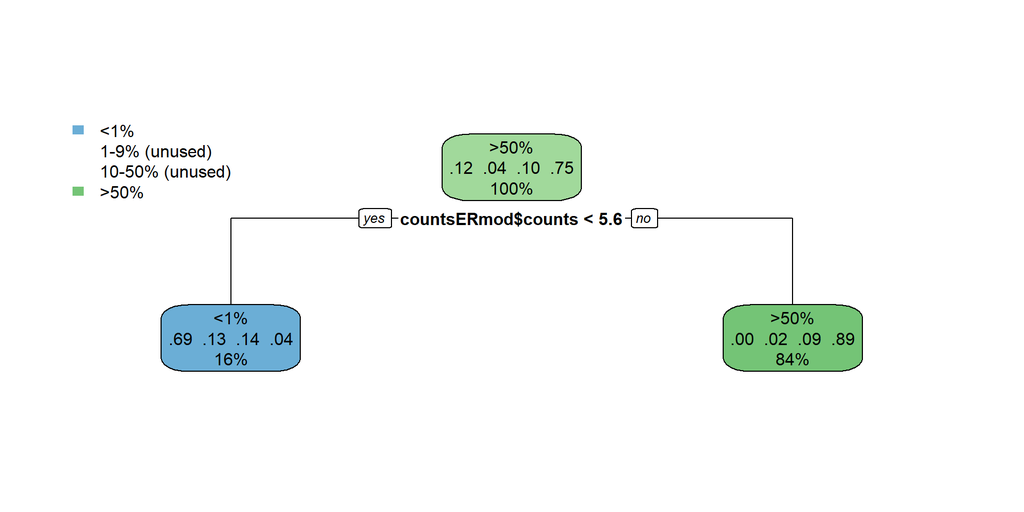

```r
# Pruned model for IHC
cart <- prune(cart, cp = bestcp)
rpart.plot(cart)  # plot
```

```r
# Contigency table
table(predict(cart, countsERmod["counts"], type = "class"), countsERmod$ER_level)
```

```
         <1% 1-9% 10-50% >50%
  <1%     53   10     11    3
  1-9%     0    0      0    0
  10-50%   0    0      0    0
  >50%     1    7     36  348
```

The pruned tree results a single binary split, basically separating the two extreme categories. We see that the cutoff point is 5.6 (number of normalized counts). This means we would have only two true categories based on the IHC classification: the tumors with an ESR1 expression lower than 5.6, and the tumors with an ESR1 expression equals or higher to 5.6.

Now let’s compute the results for the two selected alternative classifications:

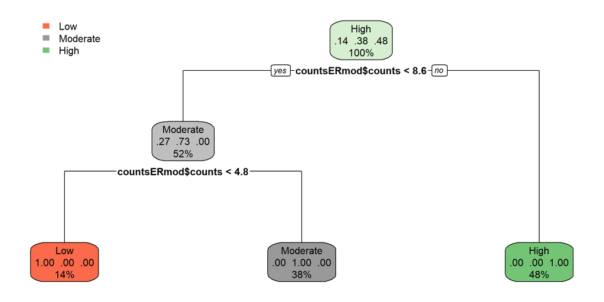

```r
# Base model for 'kmeans3'
cartalt3 <- rpart(countsERmod$kmeans3 ~ countsERmod$counts, method = "class", cp = 0)
rpart.plot(cartalt3)  # plot
```

```r
# CP that gives the smallest xerror
(bestcp <- cartalt3$cptable[which.min(cartalt3$cptable[, "xerror"]), "CP"])
```

```
[1] 0
```

```r
# Contigency table comparing 'kmeans3' and the traditional IHC classification
table(predict(cartalt3, countsERmod["counts"], type = "class"), countsERmod$ER_level)
```

```
           <1% 1-9% 10-50% >50%
  Low       46   10     10    1
  Moderate   8    4     21  144
  High       0    3     16  206
```

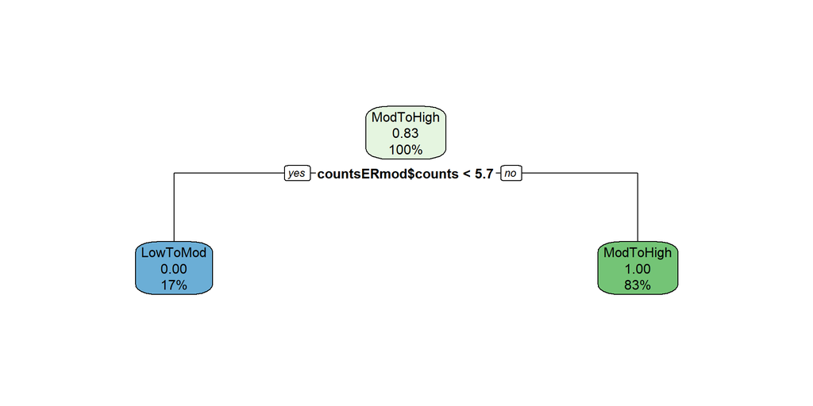

```r
# Base model for 'kmeans_GMM2'
cartalt2 <- rpart(countsERmod$kmeans_GMM2 ~ countsERmod$counts, method = "class",
    cp = 0)
rpart.plot(cartalt2)  # plot
```

```r
# CP that gives the smallest xerror
(bestcp <- cartalt2$cptable[which.min(cartalt2$cptable[, "xerror"]), "CP"])
```

```
[1] 0
```

```r
# Contigency table comparing 'kmeans_GMM2' and the traditional IHC
# classification
table(predict(cartalt2, countsERmod["counts"], type = "class"), countsERmod$ER_level)
```

```
            <1% 1-9% 10-50% >50%
  LowToMod   53   10     12    4
  ModToHigh   1    7     35  347
```

The results of these analyses with CART reinforce the message that natural clusters based on ESR1 expression offer different tresholds than the traditional ones based on IHC.